# MassDEP Stream IBI Summary Report

Metric Scores and Values

ben.block

2020-10-29 09:21:52

# INTRODUCTION

The following document is dynamic - it changes depending on the data input into the Mass DEP R Shiny Application.

Please refer to the “Data File Information” section for general properties of the input dataset used to genereate this report.

Histograms in the “Plots” section will change depending on the input dataset.

# DATA FILE INFORMATION

**Report Date:** 2020-10-29 09:21:52

**Generated By:** ben.block

**Number of Records:** 50

**Period of Record:** 2000-07-17 to 2019-08-25

# SUMMARY TABLES

### The tables below summarize the data that were input into the shiny app.

### Table 1. Number of sites by Index Narrative and Index Region.

| Index Narrative | Central Hills 100ct | Central Hills 300ct | Western Highlands 100ct | Western Highlands 300ct | Low Gradient |
| --- | --- | --- | --- | --- | --- |
| Exceptional | 1 | 2 | 2 | 1 | 3 |
| Satisfactory | 5 | 6 | 7 | 5 | 7 |
| Moderately Degraded | 2 | NA | 1 | 2 | NA |
| Severely Degraded | 2 | 2 | NA | 2 | NA |

### Table 2. Index scores summary statistics by Index Region.

| Index Region | N | Min | q25 | Med | q75 | Max |
| --- | --- | --- | --- | --- | --- | --- |
| Central Hills (100 ct) | 10 | 23.6 | 46.0 | 63.6 | 68.0 | 80.6 |
| Central Hills (300 ct) | 10 | 23.6 | 57.5 | 67.8 | 73.1 | 85.7 |
| Western Highlands (100ct) | 10 | 51.6 | 61.3 | 64.6 | 69.9 | 92.1 |
| Western Highlands (300ct) | 10 | 16.2 | 47.1 | 57.1 | 61.2 | 85.5 |
| Low Gradient | 10 | 59.0 | 63.8 | 67.9 | 75.8 | 87.4 |
| WH IBI Stress Sites (300 ct) | 42 | 16.1 | 35.4 | 44.9 | 52.2 | 77.9 |
| WH IBI Reference Sites (300 ct) | 26 | 33.2 | 59.7 | 62.5 | 75.4 | 92.9 |
| CH IBI Stress Sites (300 ct) | 30 | 13.9 | 27.4 | 35.9 | 38.3 | 63.2 |
| CH IBI Reference Sites (300 ct) | 30 | 35.9 | 64.7 | 71.0 | 79.4 | 90.6 |
| Low Gradient IBI Stress Sites | 41 | 14.0 | 30.1 | 35.1 | 48.2 | 68.8 |
| Low Gradient IBI Reference Sites | 43 | 32.9 | 67.1 | 72.1 | 80.7 | 91.3 |

### Table 3. Metrics in the Western Highlands IBI, with scoring formulas. Trend is the direction of metric response with increasing stress.

| Metric (abbrev) | Response to stress | Scoring formula |
| --- | --- | --- |
| Number of total taxa (nt_total) | Decrease | 100*(metric)/38.8 |
| % Plecoptera individuals (pi_Pleco) | Decrease | 100*(metric)/18.3 |
| % Collector-filterer individuals (pi_ffg_filt) | Increase | 100*(50.5-metric)/40.7 |
| % Shredder individuals (pi_ffg_shred) | Decrease | 100*(metric)/23 |
| % Intolerant individuals (pi_tv_intol) | Decrease | 100*(metric)/51.5 |
| Becks Biotic Index (x_Becks) | Decrease | 100*(metric)/36.8 |

### Table 4. Metrics in the Central Hills IBI, with scoring formulas. Trend is the direction of metric response with increasing stress.

| Metric (abbrev) | Response to stress | Scoring formula |
| --- | --- | --- |
| Number of total taxa (nt_total) | Decrease | 100*(metric)/34.9 |
| % EPT taxa (pt_EPT) | Decrease | 100*(metric)/54.5 |
| % Ephemeroptera individuals, excluding Caenidae and Baetidae (pi_Ephem NoCaeBae) | Decrease | 100*(metric)/13.9 |
| % Collector-filterer individuals (pi_ffg_filt) | Increase | 100*(79.9-metric)/66.9 |
| % Predator taxa (pt_ffg_pred) | Decrease | 100*(metric)/28.5 |
| % Intolerant taxa (pt_tv_intol) | Decrease | 100*(metric)/39.1 |

### Table 5. Metrics in the Low Gradient IBI, with scoring formulas. Trend is the direction of metric response with increasing stress.

| Metric (abbrev) | Response to stress | Scoring formula |
| --- | --- | --- |
| % POET taxa (Plecoptera, Odonata, Ephemeroptera, and Trichoptera) (pt_POET) | Decrease | 100*(metric)/40 |
| % Predator taxa (pt_ffg_pred) | Decrease | 100*(metric)/32 |
| % Non-insect taxa (pt_NonIns) | Increase | 100*(46-metric)/42 |
| % OET individuals (Odonata, Ephemeroptera, and Trichoptera) (pi_OET) | Decrease | 100*(metric)/49 |
| % Tolerant taxa (pt_tv_toler) | Increase | 100*(36-metric)/33 |
| % Semivoltine taxa (pt_volt_semi) | Decrease | 100*(metric)/12 |

# PLOTS

## Map of Sites in Massachusetts

These are the sites that have been input into the R shiny application.

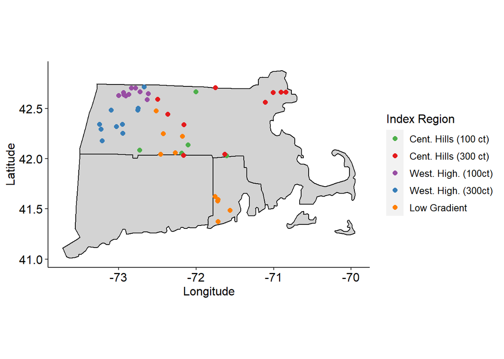

## Overall Index Scores by Index Region

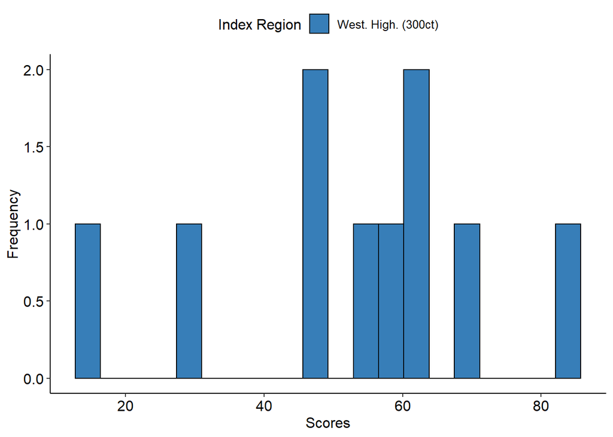

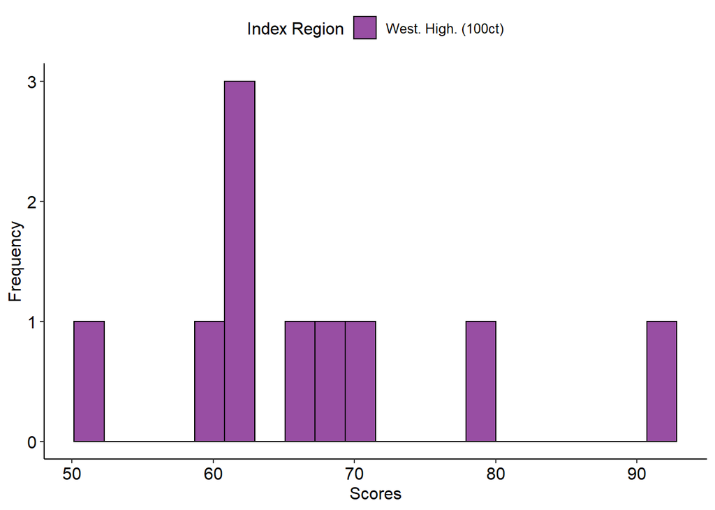

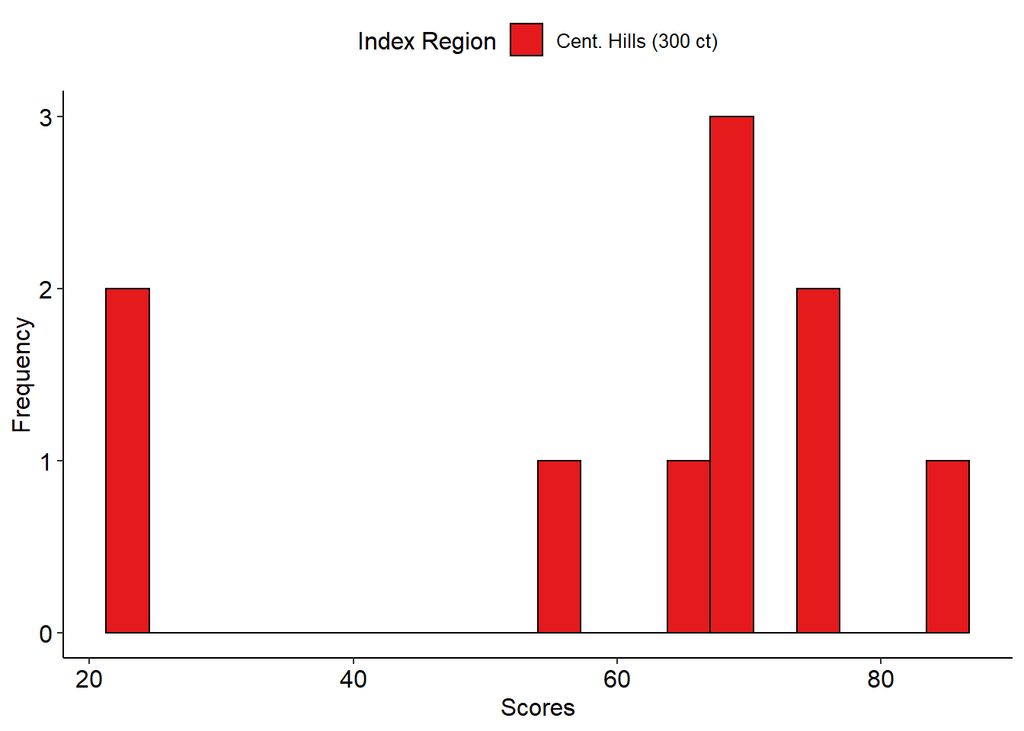

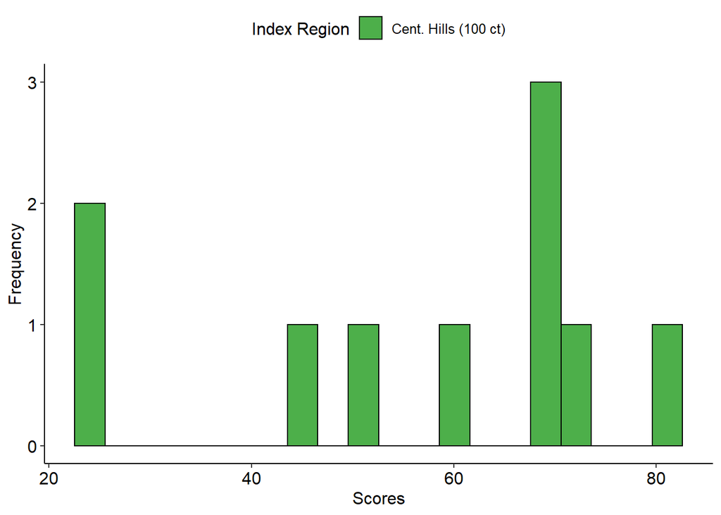

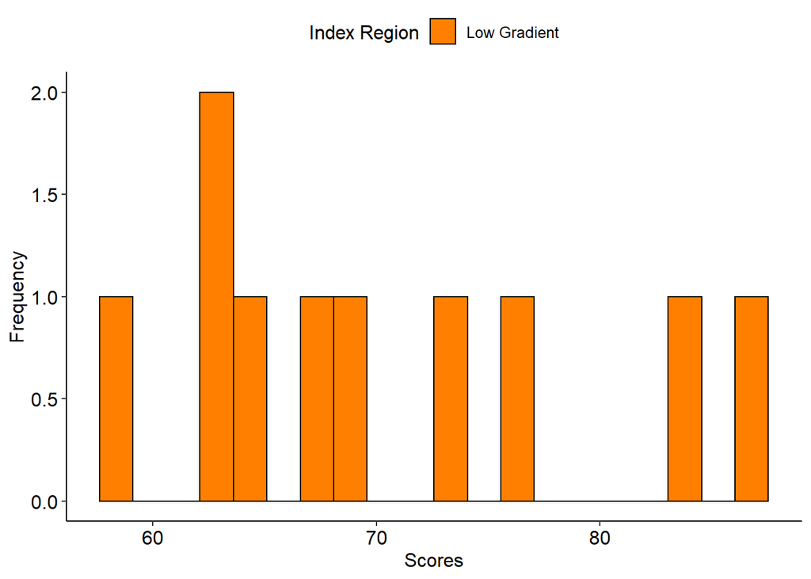

## Metric Values Distribution by Index Region.

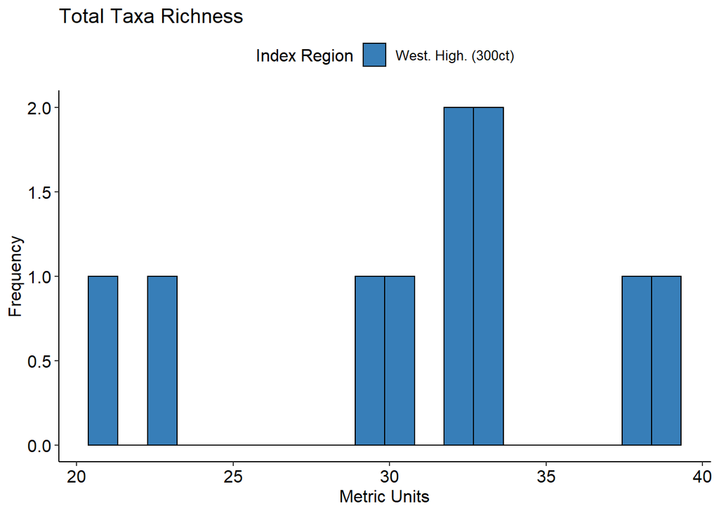

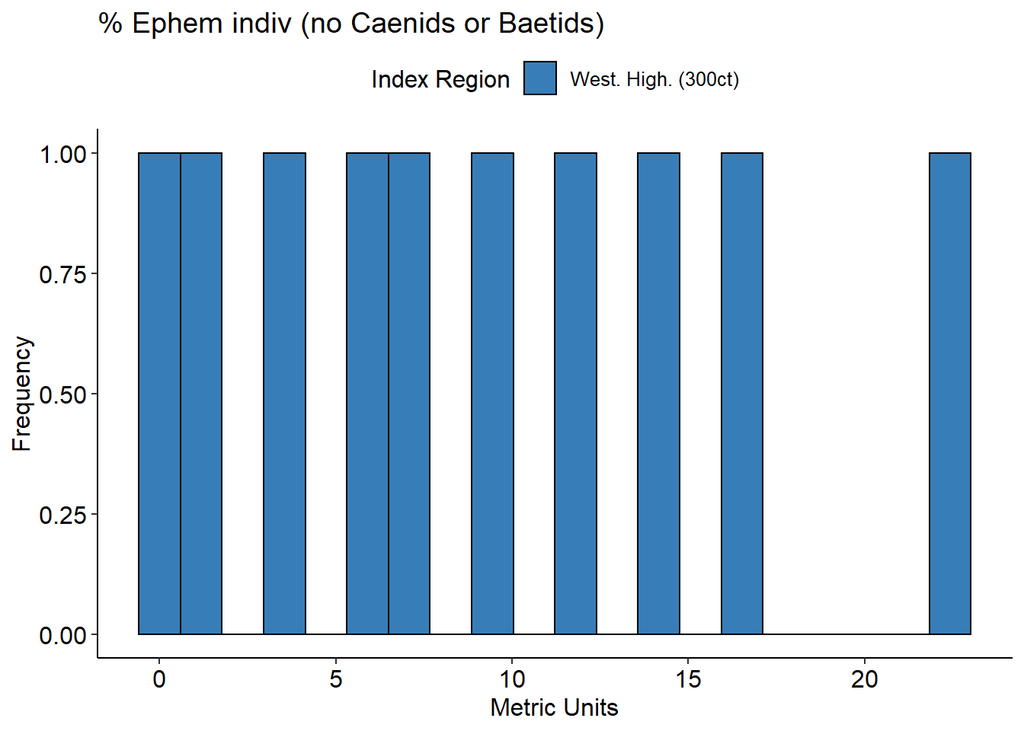

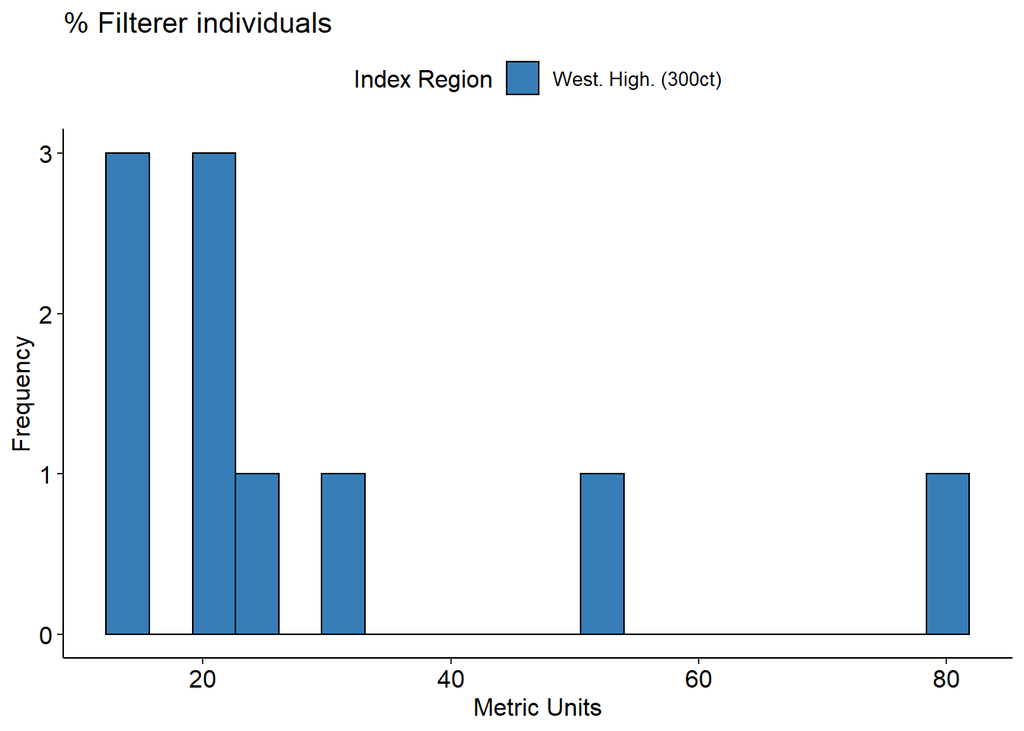

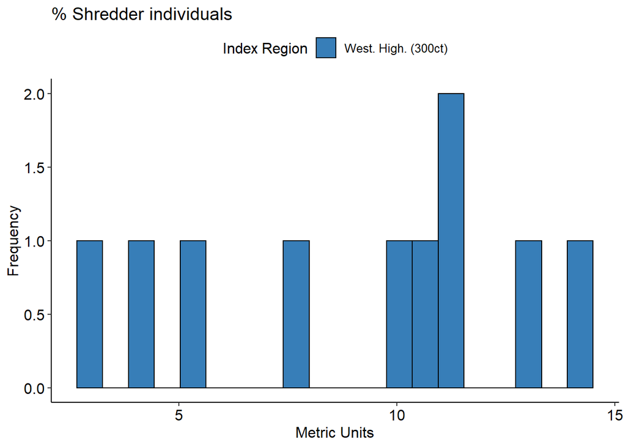

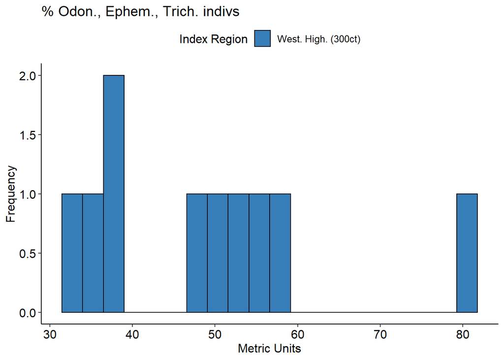

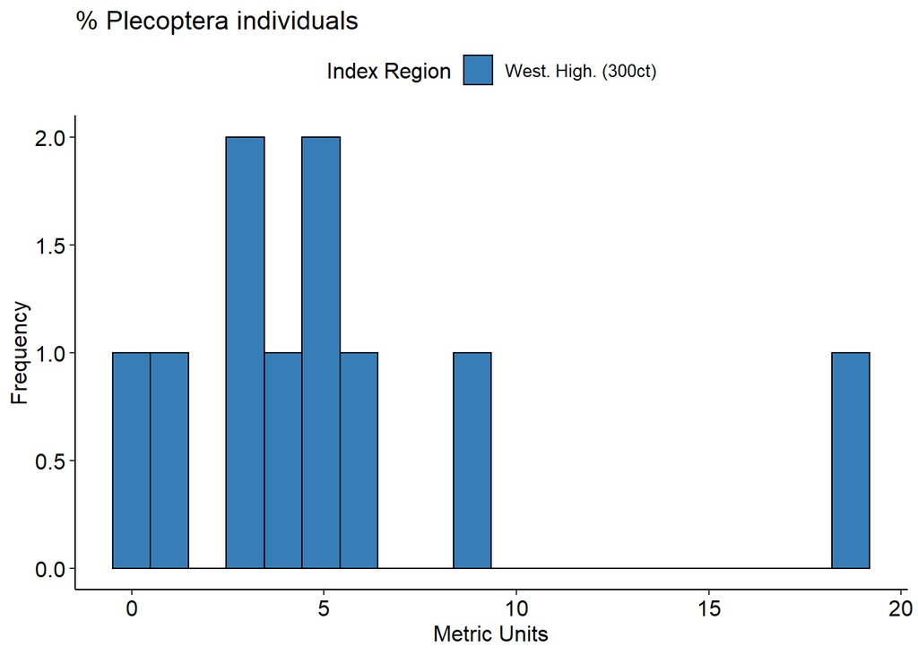

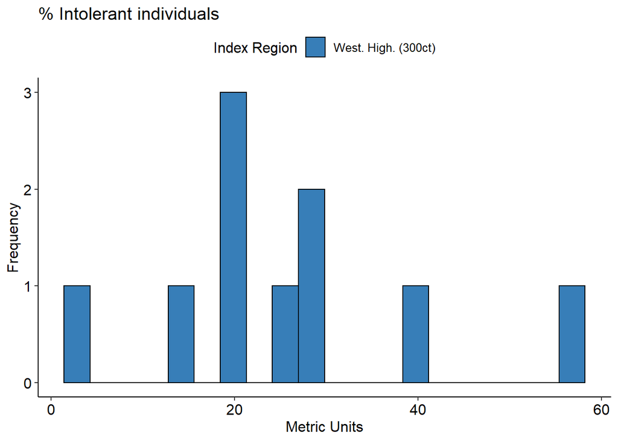

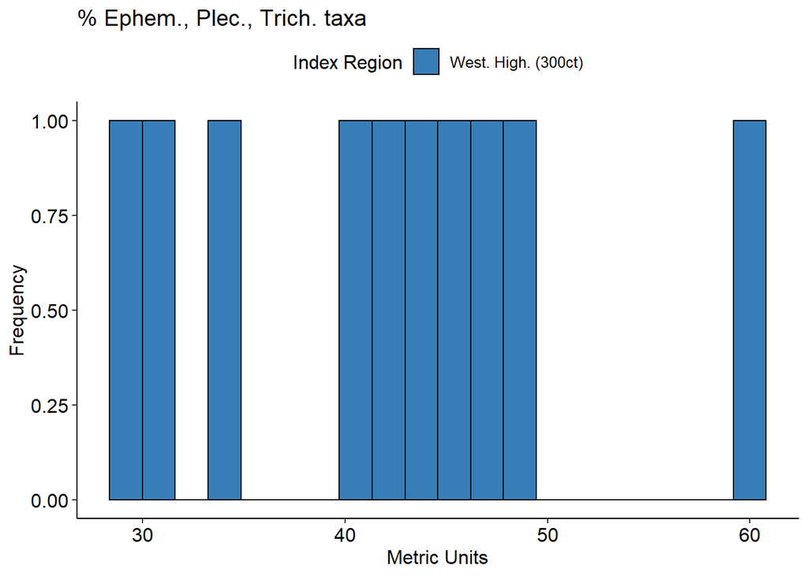

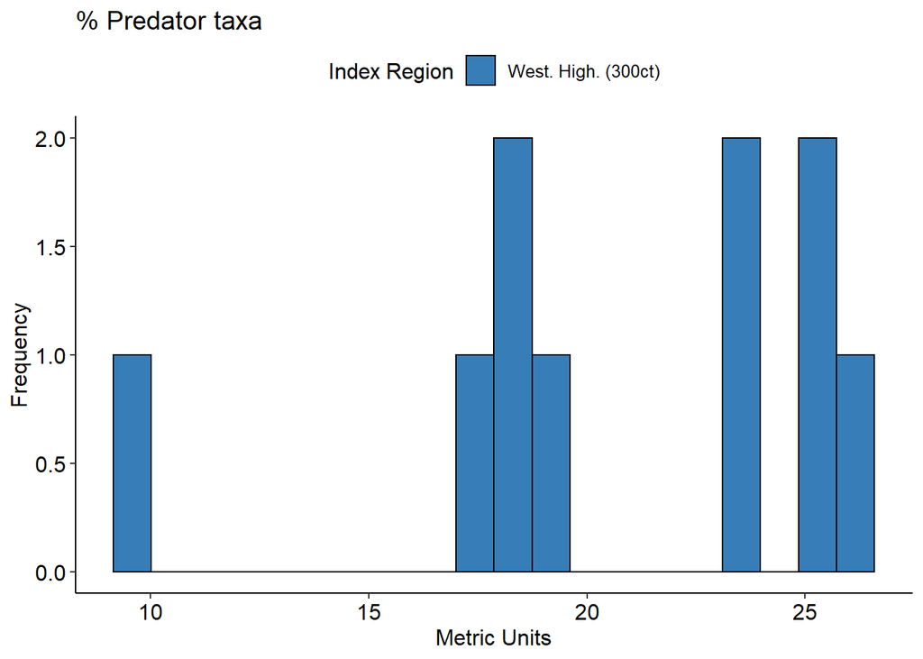

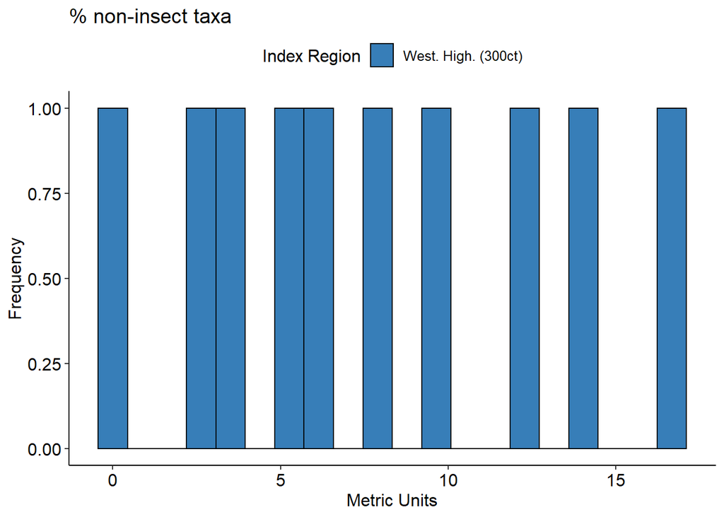

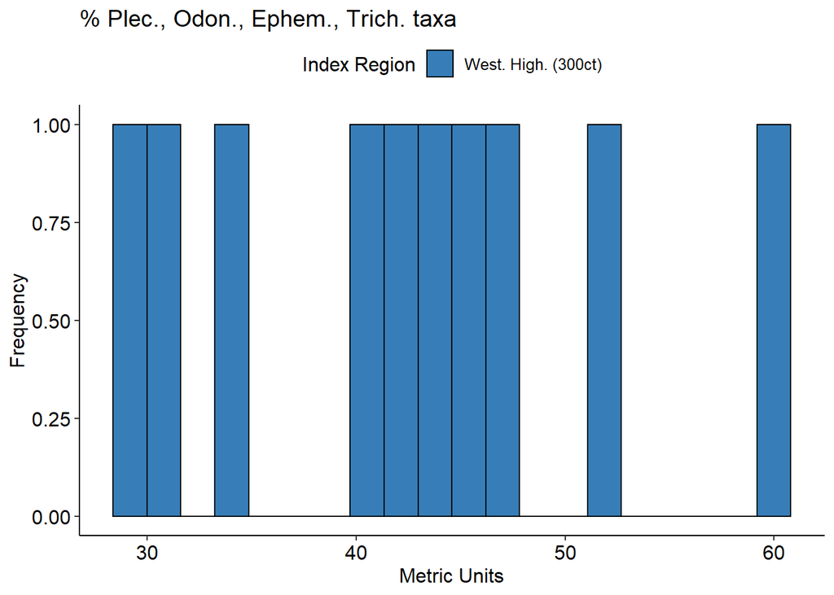

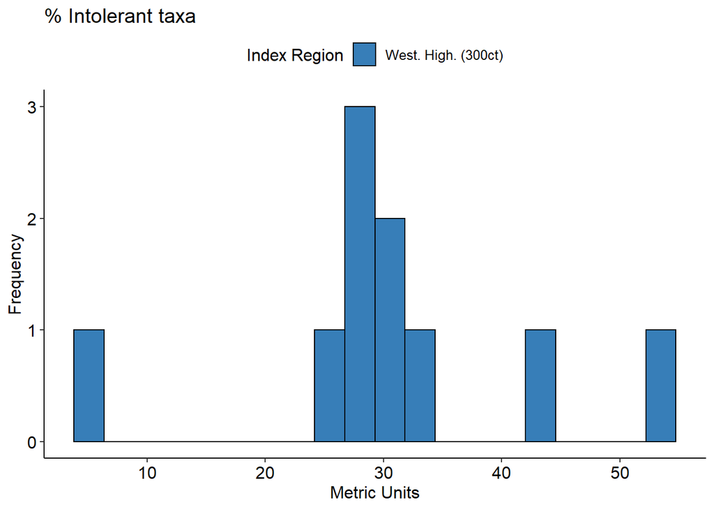

[63 more figures not shown]

## Metric Scores Distribution by Index Region.

Only metrics applied within each region are plotted.

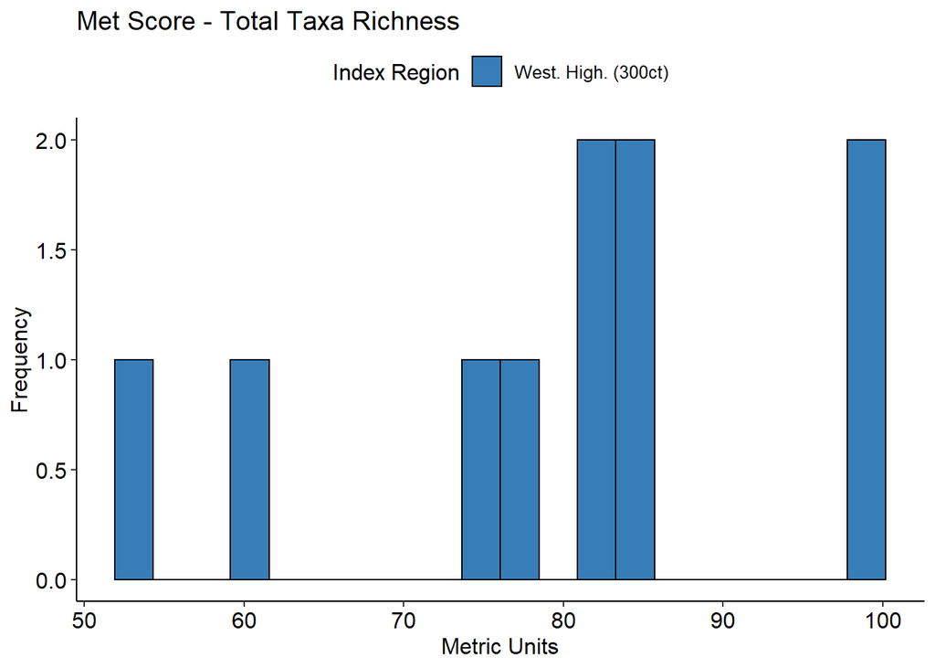

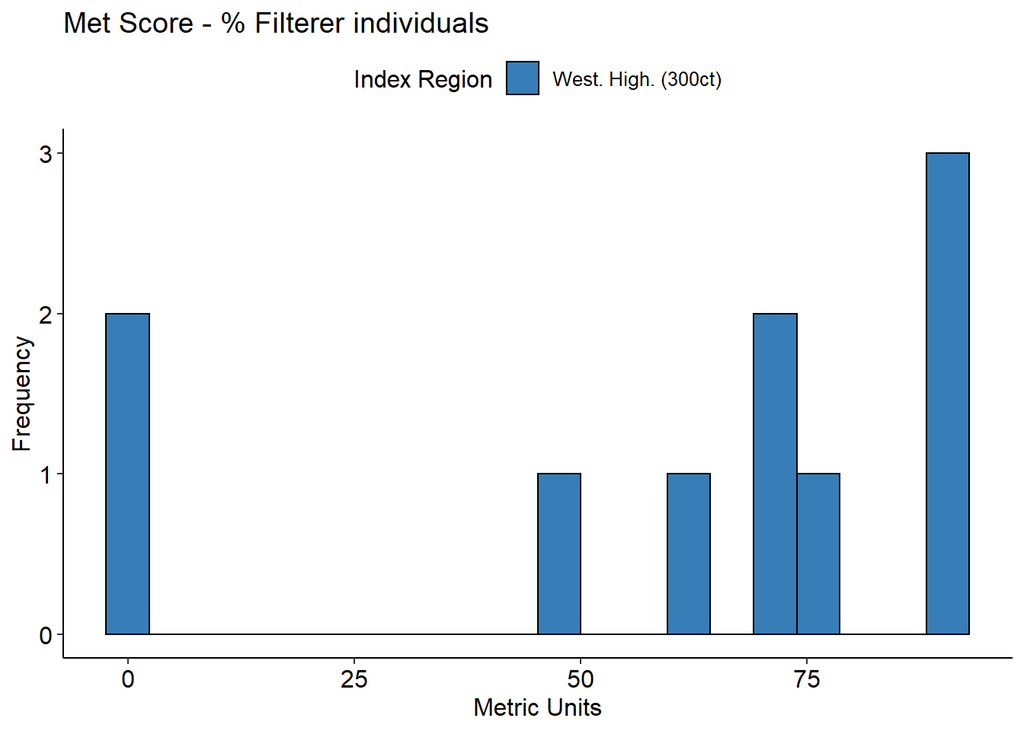

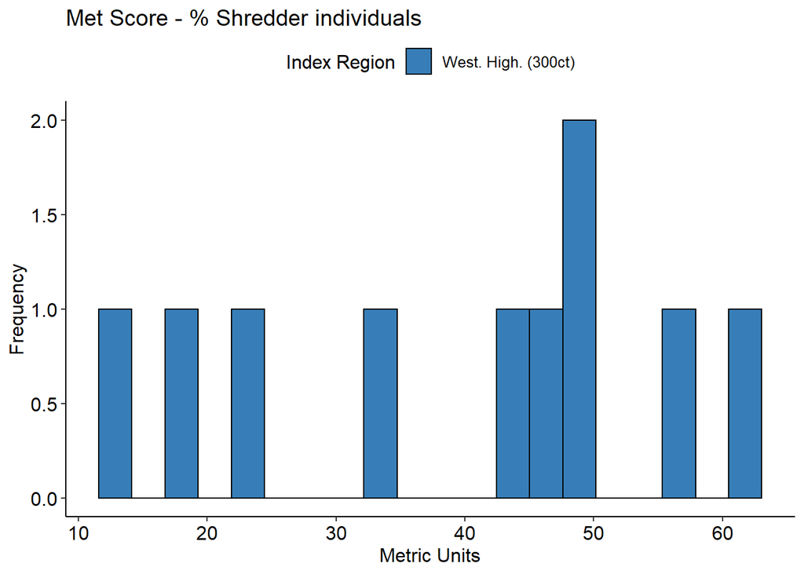

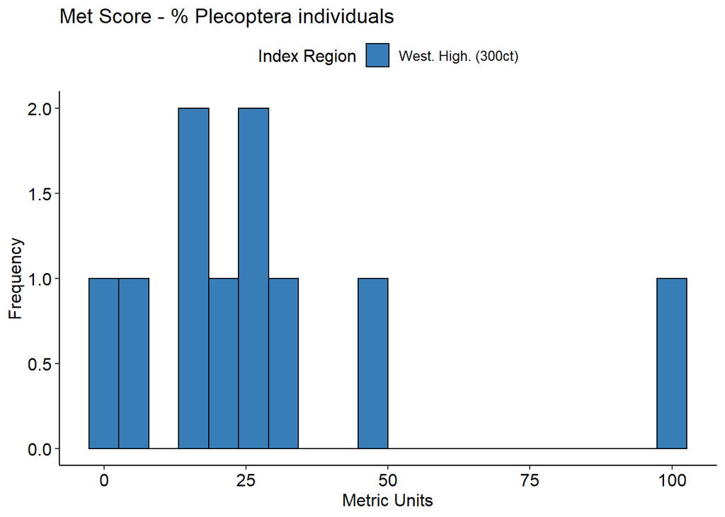

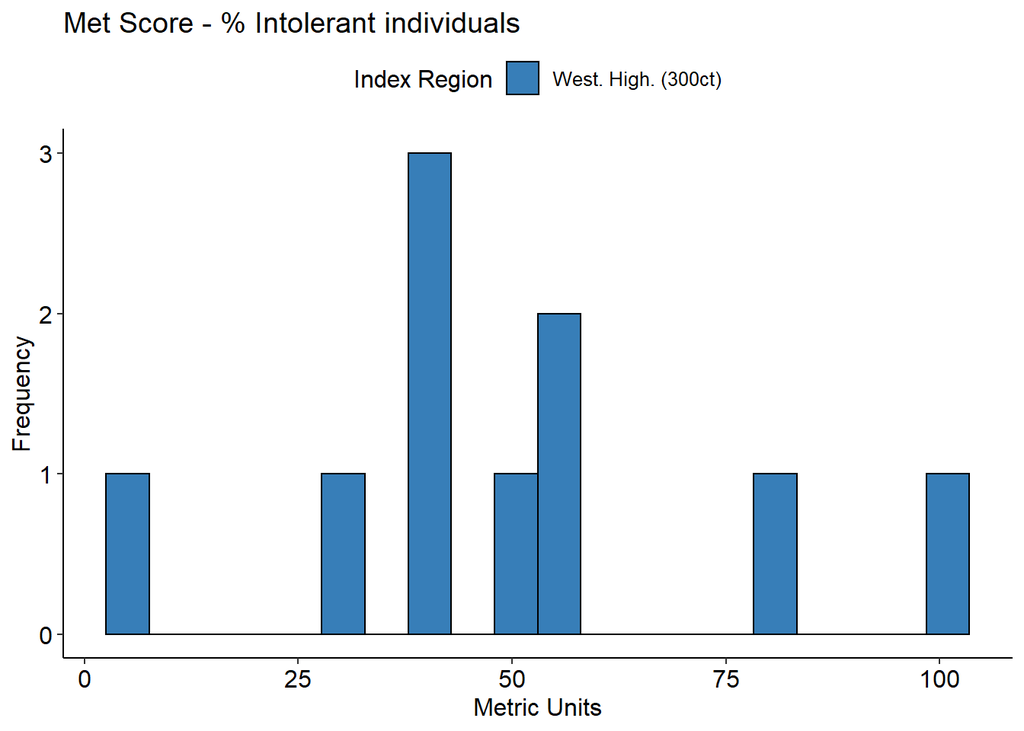

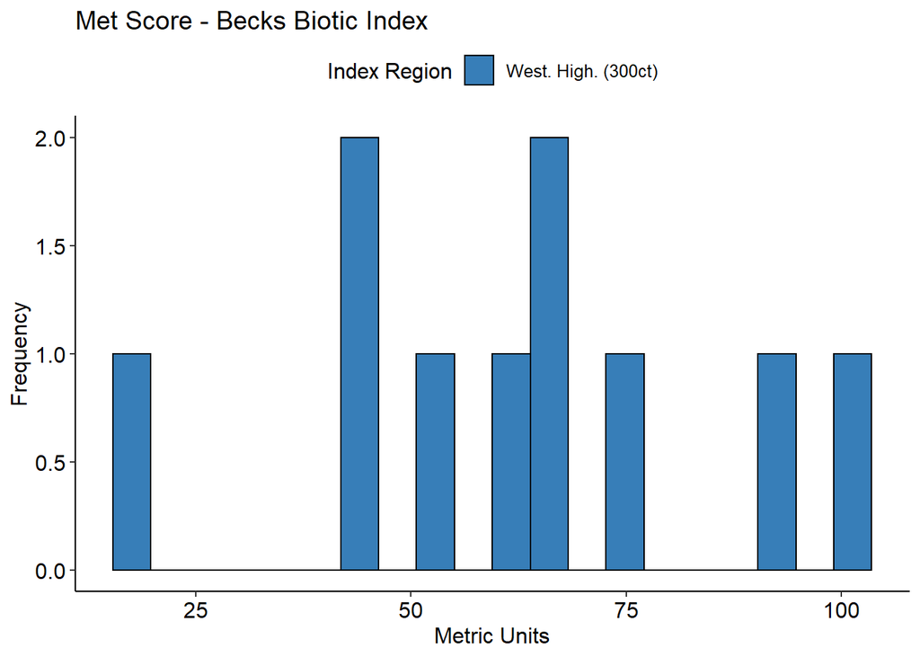

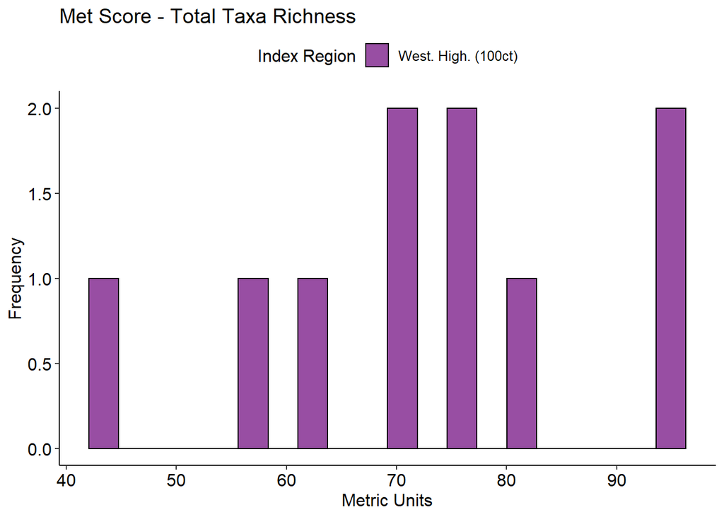

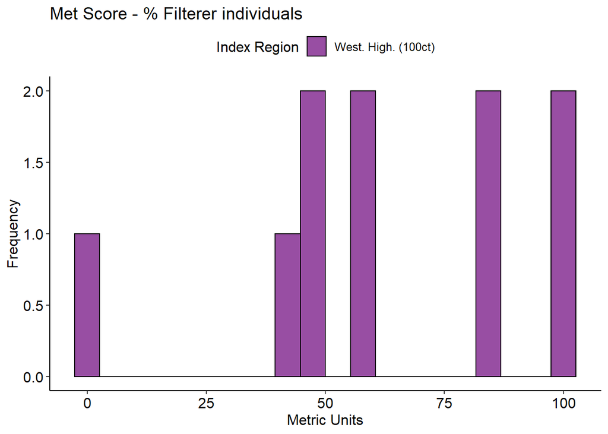

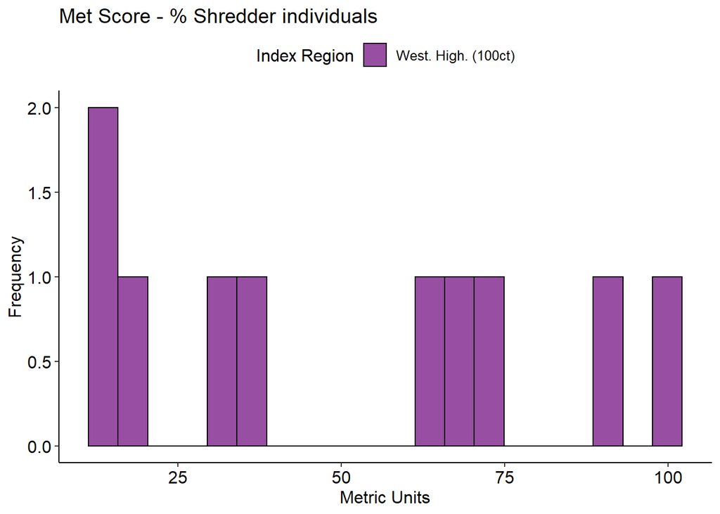

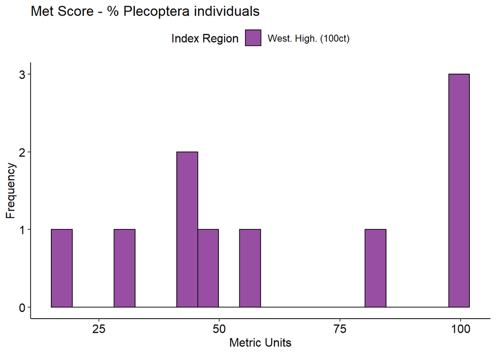

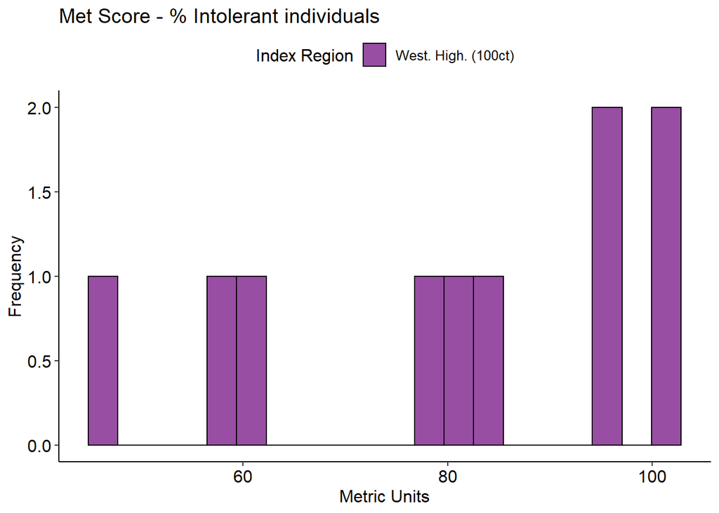

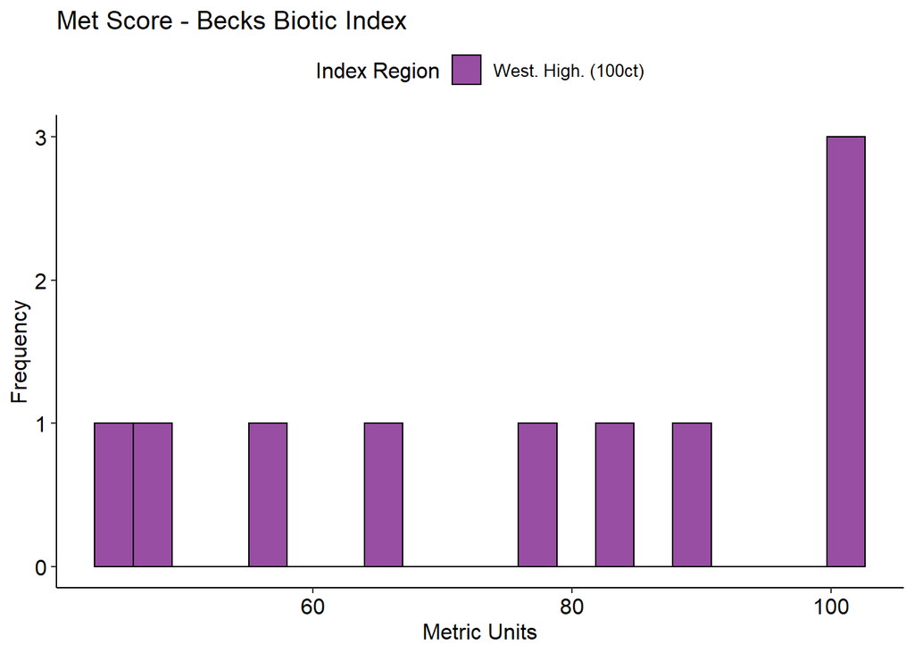

[18 more figures not shown]